# ErinRoss_Lab4

Author

Erin Ross

### **1. Read in the data**

```r
setwd('/Users/erinross/Desktop/PM566/DATA/')

library(data.table)
library(ggplot2)
library(magrittr)
library(RColorBrewer)
library(Hmisc)
library(leaflet)
library(ggpubr)
library(tidyverse)
met <- data.table::fread("met_all.gz")
str(met)
```

```
Classes 'data.table' and 'data.frame':  2377343 obs. of  30 variables:
 $ USAFID           : int  690150 690150 690150 690150 690150 690150 690150 690150 690150 690150 ...
 $ WBAN             : int  93121 93121 93121 93121 93121 93121 93121 93121 93121 93121 ...
 $ year             : int  2019 2019 2019 2019 2019 2019 2019 2019 2019 2019 ...
 $ month            : int  8 8 8 8 8 8 8 8 8 8 ...
 $ day              : int  1 1 1 1 1 1 1 1 1 1 ...
 $ hour             : int  0 1 2 3 4 5 6 7 8 9 ...
 $ min              : int  56 56 56 56 56 56 56 56 56 56 ...
 $ lat              : num  34.3 34.3 34.3 34.3 34.3 34.3 34.3 34.3 34.3 34.3 ...
 $ lon              : num  -116 -116 -116 -116 -116 ...
 $ elev             : int  696 696 696 696 696 696 696 696 696 696 ...
 $ wind.dir         : int  220 230 230 210 120 NA 320 10 320 350 ...
 $ wind.dir.qc      : chr  "5" "5" "5" "5" ...
 $ wind.type.code   : chr  "N" "N" "N" "N" ...
 $ wind.sp          : num  5.7 8.2 6.7 5.1 2.1 0 1.5 2.1 2.6 1.5 ...
```

[output cut: 17 more lines]

### **2. Prepare the data**

```r
met.clean<- met[temp >-17,]
summary(met.clean$temp)
```

```
   Min. 1st Qu.  Median    Mean 3rd Qu.    Max.
  -3.00   19.60   23.50   23.59   27.80   56.00
```

```r
summary(met.clean$elev)
```

```
   Min. 1st Qu.  Median    Mean 3rd Qu.    Max.
  -13.0   101.0   252.0   415.1   400.0  9999.0
```

```r
met.clean$elev[met.clean$elev == 9999.0] <- NA
summary(met.clean$elev)
```

```
   Min. 1st Qu.  Median    Mean 3rd Qu.    Max.    NA's
  -13.0   101.0   252.0   414.3   400.0  4113.0     182
```

```r
summary(met.clean$lat)
```

```
   Min. 1st Qu.  Median    Mean 3rd Qu.    Max.
  24.55   33.98   38.37   37.97   41.96   48.94
```

```r
summary(met.clean$lon)
```

```
   Min. 1st Qu.  Median    Mean 3rd Qu.    Max.
-124.29  -98.02  -91.74  -92.14  -82.99  -68.31
```

```r
met.clean$date <- paste(met.clean$year, met.clean$month, met.clean$day, sep = "-")
met.clean$date <- as.Date(met.clean$date)

met.clean$week <- data.table::week(met.clean$date) # All observations in one month1
summary(met.clean$week)
```

```
   Min. 1st Qu.  Median    Mean 3rd Qu.    Max.
  31.00   32.00   33.00   33.13   34.00   35.00
```

```r
met.week1 <- met.clean[week <33]
table(met.week1$day, met.week1$week) #pick out what days we have in weeks 31 and 32
```

```
        31    32
  1  73681     0
  2  74036     0
  3  74983     0
  4  74559     0
  5      0 74285
  6      0 74610
  7      0 75586
  8      0 75679
  9      0 73452
  10     0 73660
  11     0 74328
```

```r
met.week1 <- met.week1[day <8]

#Mean by station variables
met.avgs <- met.week1[,.(
  temp     = mean(temp,na.rm=TRUE),
  rh       = mean(rh,na.rm=TRUE),
  wind.sp  = mean(wind.sp,na.rm=TRUE),
  vis.dist = mean(vis.dist,na.rm=TRUE),
  dew.point = mean(dew.point,na.rm=TRUE),
  lat      = mean(lat),
  lon      = mean(lon),
  elev     = mean(elev,na.rm=TRUE)
), by=c("USAFID", "day")]

#Region variable NW, SW, NE, SE lon = -98.00 and lat = 39.71
met.avgs$region[met.avgs$lon < -98.00 & met.avgs$lat >39.71] <- "SW"
met.avgs$region[met.avgs$lon < -98.00 & met.avgs$lat <39.71] <- "SE"
met.avgs$region[met.avgs$lon > -98.00 & met.avgs$lat <39.71] <- "NE"
met.avgs$region[met.avgs$lon > -98.00 & met.avgs$lat >39.71] <- "NW"
table(met.avgs$region)
```

```
  NE   NW   SE   SW
4524 3382 2071 1022
```

```r
#Elevation categories
met.avgs$elev_cat[met.avgs$elev > 252] <- "high"
met.avgs$elev_cat[met.avgs$elev < 253] <- "low"
summary(met.avgs$elev)
```

```
   Min. 1st Qu.  Median    Mean 3rd Qu.    Max.    NA's
  -12.0    90.0   238.0   416.9   404.0  4113.0       2
```

### **3. Use `geom_violin` to examine the wind speed and dew point by region**

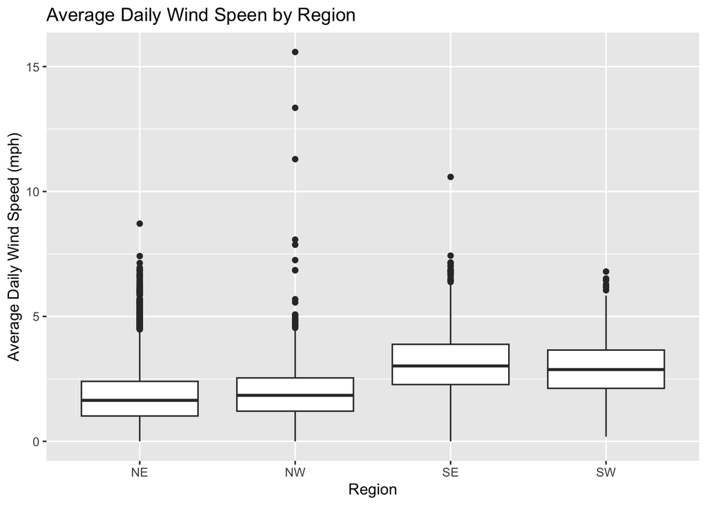

```r
ggplot(met.avgs) + geom_boxplot(aes(x=region, y= wind.sp)) +
  labs(title = "Average Daily Wind Speen by Region",
       x = "Region",
       y = "Average Daily Wind Speed (mph)")
```

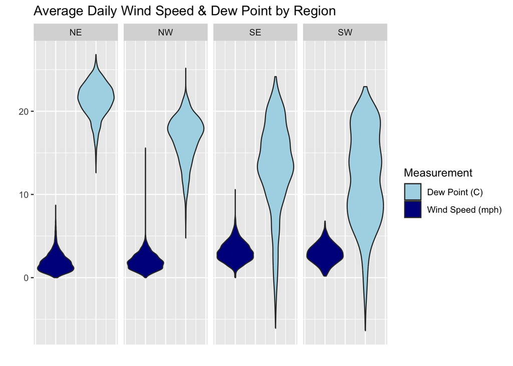

```r
# Plot wind speed + dew point by region
ggplot(met.avgs) +
  geom_violin(aes(x=1, y= wind.sp, group = region, fill = "Wind Speed (mph)")) +
  labs(title = "Average Daily Wind Speed & Dew Point by Region",
       y = "",
       x = "") +
  geom_violin(aes(x=2, y= dew.point, group = region, fill = "Dew Point (C)")) +
  scale_fill_manual(values = c("lightblue","darkblue"),name="Measurement") +
  facet_wrap(~region, nrow = 1) +
  theme(axis.text.x=element_blank(),
        axis.ticks.x=element_blank())
```

The wind speed for each region is similar and has a smaller range compared to wind speed. Dew point is more variable , and probably lower, in the South.

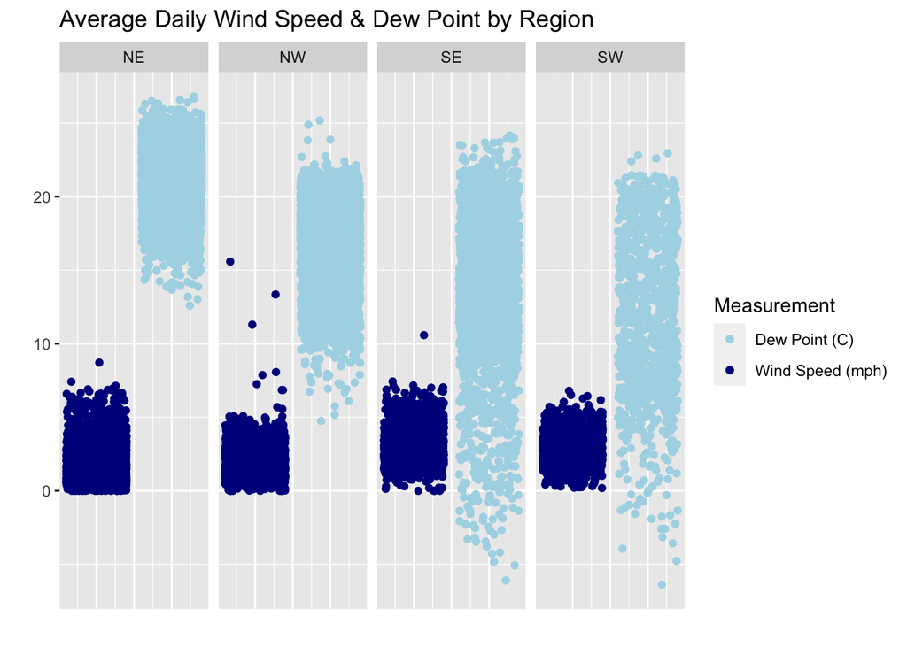

```r
ggplot(met.avgs) +
  geom_jitter(aes(x=1, y= wind.sp, group = region, color = "Wind Speed (mph)")) +
  labs(title = "Average Daily Wind Speed & Dew Point by Region",
       y = "",
       x = "") +
  geom_jitter(aes(x=2, y= dew.point, group = region, color = "Dew Point (C)")) +
  scale_color_manual(values = c("lightblue","darkblue"),name="Measurement") +
  facet_wrap(~region, nrow = 1) +
  theme(axis.text.x=element_blank(),
        axis.ticks.x=element_blank())
```

We see that wind speed remains clustered near but never below zero (makes sense) vs dew point is much more variable and can go below zero (makes sense). Wind speeds similar across regions, NE may have higher dew point compared other regions.

### **4. Use `geom_jitter` with `stat_smooth` to examine the association between dew point and wind speed by region**

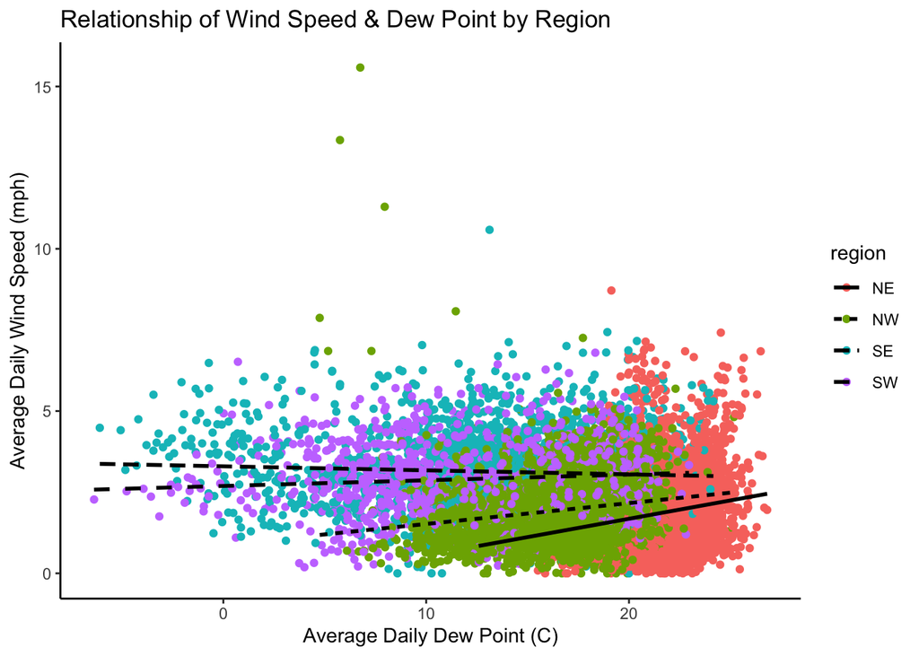

```r
ggplot(met.avgs, aes(x=dew.point, y= wind.sp, color = region, linetype = region)) +
  geom_point() +
  labs(title = "Relationship of Wind Speed & Dew Point by Region",
       y = "Average Daily Wind Speed (mph)",
       x = "Average Daily Dew Point (C)") +
  theme_classic() +
  geom_smooth(method = lm, se = FALSE, col = "black")
```

```r
  #guide_legend(title = "Region") why won't you rename this legend
```

There is not a strong relationship between wind speed and dew point since the regression lines are slope ~0.

### **5. Use `geom_bar` to create barplots of the weather stations by elevation category colored by region**

```r
# weather stations by elevation by region
str(met.avgs)
```

```
Classes 'data.table' and 'data.frame':  10999 obs. of  12 variables:
 $ USAFID   : int  690150 690150 690150 690150 690150 690150 690150 720110 720110 720110 ...
 $ day      : int  1 2 3 4 5 6 7 1 2 3 ...
 $ temp     : num  32.6 33.5 34.3 34.7 34.8 ...
 $ rh       : num  20.7 13.2 14.2 11.7 13.2 ...
 $ wind.sp  : num  2.9 4.15 4.43 4.25 3.66 ...
 $ vis.dist : num  15959 16093 16026 16093 15953 ...
 $ dew.point: num  6.3 1.217 2.496 0.554 1.496 ...
 $ lat      : num  34.3 34.3 34.3 34.3 34.3 ...
 $ lon      : num  -116 -116 -116 -116 -116 ...
 $ elev     : num  690 696 696 696 696 ...
 $ region   : chr  "SE" "SE" "SE" "SE" ...
 $ elev_cat : chr  "high" "high" "high" "high" ...
 - attr(*, ".internal.selfref")=<externalptr>
```

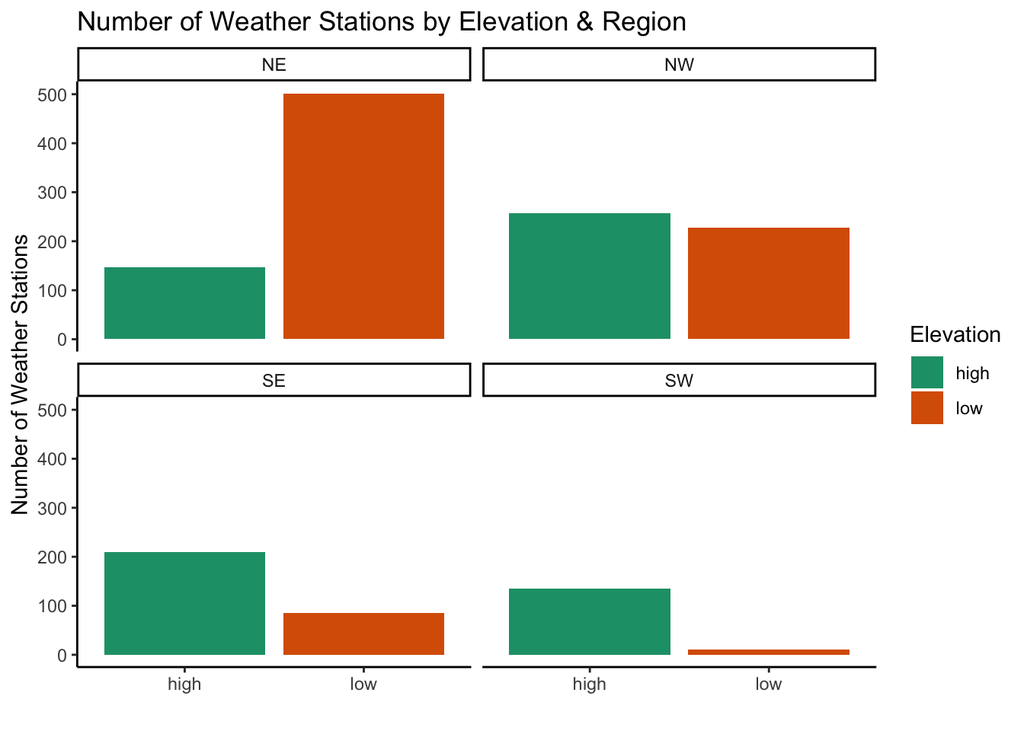

```r
met.day1avg <- met.avgs[day ==1] #make each weather station appear only once
ggplot(met.day1avg) + geom_bar(aes(x=elev_cat, group = elev_cat, fill = elev_cat), stat="count") +
  labs(title = "Number of Weather Stations by Elevation & Region",
       y = "Number of Weather Stations",
       x = "") +
  theme_classic() +
  scale_fill_brewer(palette = "Dark2", name = "Elevation") +
  facet_wrap(~region)
```

### **6. Use `stat_summary` to examine mean dew point and wind speed by region with standard deviation error bars**

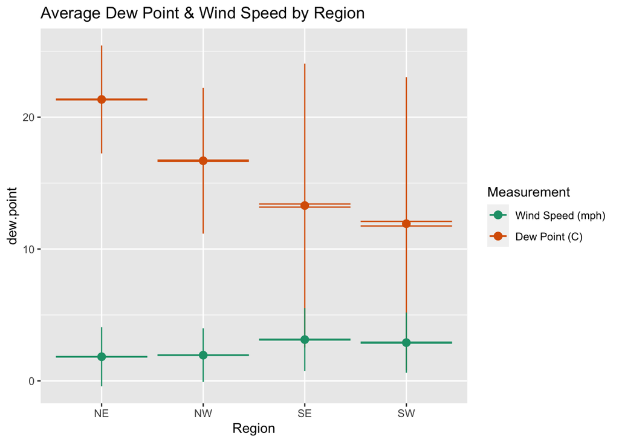

```r
ggplot(met.avgs) +
  stat_summary(mapping = aes(x = dew.point, y = region, color = "red"),
               fun.data="mean_sdl",
               fun = mean) +
    stat_summary(mapping = aes(x = dew.point, y = region, color = "red"),
                 fun.data = mean_se,
                 geom = "errorbar") +
    stat_summary(mapping = aes(x = wind.sp, y = region, color = "blue"),
               fun.data="mean_sdl",
               fun = mean) +
    stat_summary(mapping = aes(x = wind.sp, y = region, color = "blue"),
                 fun.data = mean_se,
                 geom = "errorbar") +
  coord_flip() +
  labs(title = "Average Dew Point & Wind Speed by Region",
      y = "Region") +
  scale_color_brewer(palette = "Dark2", labels = c("Wind Speed (mph)","Dew Point (C)"), name = "Measurement")
```

- The spread of dew point is greater than the dispersion of wind speed, however the standard error looks pretty small (probably did this wrong).

### **7. Make a map showing the spatial trend in relative humidity in the US**

```r
met.rh <- met.avgs[!is.na(rh)]

str(met.avgs)
```

```
Classes 'data.table' and 'data.frame':  10999 obs. of  12 variables:
 $ USAFID   : int  690150 690150 690150 690150 690150 690150 690150 720110 720110 720110 ...
 $ day      : int  1 2 3 4 5 6 7 1 2 3 ...
 $ temp     : num  32.6 33.5 34.3 34.7 34.8 ...
 $ rh       : num  20.7 13.2 14.2 11.7 13.2 ...
 $ wind.sp  : num  2.9 4.15 4.43 4.25 3.66 ...
 $ vis.dist : num  15959 16093 16026 16093 15953 ...
 $ dew.point: num  6.3 1.217 2.496 0.554 1.496 ...
 $ lat      : num  34.3 34.3 34.3 34.3 34.3 ...
 $ lon      : num  -116 -116 -116 -116 -116 ...
 $ elev     : num  690 696 696 696 696 ...
 $ region   : chr  "SE" "SE" "SE" "SE" ...
 $ elev_cat : chr  "high" "high" "high" "high" ...
 - attr(*, ".internal.selfref")=<externalptr>
 - attr(*, "index")= int(0)
  ..- attr(*, "__day")= int [1:10999] 1 8 15 22 29 36 43 50 57 63 ...
```

```r
summary(met.rh$rh)
```

```
   Min. 1st Qu.  Median    Mean 3rd Qu.    Max.
  8.977  63.264  73.815  69.859  80.828 100.000
```

```r
# Generating a color palette
rh.pal <- colorNumeric(c('lightblue','blue','darkblue'), domain=met.rh$rh)
rh.pal
```

[output not shown]

```r
met.rh
```

```
       USAFID   day     temp       rh  wind.sp vis.dist  dew.point      lat
        <int> <int>    <num>    <num>    <num>    <num>      <num>    <num>
    1: 690150     1 32.59583 20.65546 2.895833 15958.92  6.3000000 34.29967
    2: 690150     2 33.54167 13.18436 4.154167 16093.00  1.2166667 34.30000
    3: 690150     3 34.30833 14.20129 4.433333 16025.96  2.4958333 34.30000
    4: 690150     4 34.72083 11.70307 4.245833 16093.00  0.5541667 34.30000
    5: 690150     5 34.77391 13.20827 3.660870 15953.09  1.4956522 34.30000
   ---
10991: 726813     3 26.03333 43.91958 3.583333 16093.00 12.0166667 43.65000
10992: 726813     4 26.58333 43.03092 2.291667 16025.96 11.8833333 43.65000
10993: 726813     5 27.41667 42.24018 2.270833 15891.88 12.3458333 43.65000
10994: 726813     6 26.69167 50.63306 1.833333 15958.92 13.9583333 43.65000
10995: 726813     7 25.83333 48.13601 1.475000 16093.00 12.3833333 43.65000
             lon     elev region elev_cat
           <num>    <num> <char>   <char>
    1: -116.1657 690.0833     SE     high
    2: -116.1660 696.0000     SE     high
    3: -116.1660 696.0000     SE     high
    4: -116.1660 696.0000     SE     high
    5: -116.1660 696.0000     SE     high
   ---
10991: -116.6330 741.0000     SW     high
10992: -116.6330 741.0000     SW     high
10993: -116.6330 741.0000     SW     high
10994: -116.6330 741.0000     SW     high
10995: -116.6330 741.0000     SW     high
```

```r
order.humidity<-order(met.rh$rh)
humid.places<-met.rh[order.humidity,]

humid.places$ranking <- NA
humid.places$ranking[order.humidity] <- 1:nrow(humid.places)

RHmap <- leaflet(humid.places) %>%
  addProviderTiles('CartoDB.Positron')   %>%
  addCircles(
    lat = ~lat, lng=~lon,
    label = ~paste0(round(temp,2), ' C'), color = ~ rh.pal(rh),
    opacity = 1, fillOpacity = 1, radius = 500)  %>%
  addLegend('bottomleft', pal=rh.pal, values=humid.places$rh,
          title='Relative Humidity (%)', opacity=1) %>%
  addMarkers(lat = ~lat, lng=~lon,
              label= ~ifelse(humid.places$ranking <11, as.character(USAFID),""))
RHmap
```

[interactive chart not shown]

More humid on east coast/south, less humid in west/mountain regions.

### **8. Use a ggplot extension**

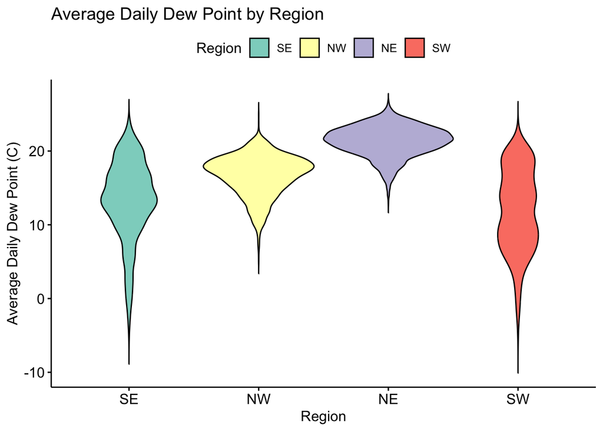

```r
#ggpubr
#Compare dew point by region
regional_comparision <- list(c("NW","NE"), c("NW","SW"), c("NW","SE"), c("NE","SW"), c("NE","SE"), c("SE","SW"))

met.avgsdf <- as.data.frame(met.avgs)
met.avgsdf <- met.avgsdf[!is.na(met.avgsdf$dew.point),] #remove NA for dew point

ggviolin(met.avgsdf, x= "region", y = "dew.point", fill = "region") +
  labs(title = "Average Daily Dew Point by Region",
       y = "Average Daily Dew Point (C)",
       x = "Region") +
  scale_fill_brewer(palette = "Set3", name = "Region")
```

```r
# stat_compare_means(method = t.test, comparisons = regional_comparision) I cannot get this to work, getting "Error in match(x, table, nomatch = 0L):'match' requires vector arguments"
```